# Assignment C

## Instructions

1. You may talk to a friend, discuss the questions and potential directions for solving them. However, you need to write your own solutions and code separately, and not as a group activity.
2. Write your code in the *Code* cells and your answer in the *Markdown* cells of the Jupyter notebook. Ensure that the solution is written neatly enough to understand and grade.
3. Use [Quarto](https://quarto.org/docs/output-formats/html-basics.html) to print the *.ipynb* file as HTML. You will need to open the command prompt, navigate to the directory containing the file, and use the command: `quarto render filename.ipynb --to html`. Submit the HTML file.
4. The assignment is worth 100 points, and is due on **Sunday, 7th May 2023 at 11:59 pm**.
5. **Five points are properly formatting the assignment**. The breakdown is as follows:
- Must be an HTML file rendered using Quarto (2 pts). *If you have a Quarto issue, you must mention the issue & quote the error you get when rendering using Quarto in the comments section of Canvas, and submit the ipynb file. If your issue doesn’t seem genuine, you will lose points.*
- There aren’t excessively long outputs of extraneous information (e.g. no printouts of entire data frames without good reason, there aren’t long printouts of which iteration a loop is on, there aren’t long sections of commented-out code, etc.) (1 pt)
- Final answers of each question are written in Markdown cells (1 pt).
- There is no piece of unnecessary / redundant code, and no unnecessary / redundant text (1 pt)

```python
from sklearn.linear_model import LogisticRegression, LinearRegression
from sklearn.model_selection import train_test_split, cross_val_predict, cross_val_score
import pandas as pd
import numpy as np
import matplotlib.pyplot as plt
import seaborn as sns
from sklearn.preprocessing import StandardScaler
from sklearn.metrics import accuracy_score, mean_absolute_error, mean_squared_error, r2_score, \
roc_curve, auc, precision_score, recall_score, confusion_matrix
import statsmodels.formula.api as smf
from sklearn.metrics import roc_curve, precision_recall_curve, auc, make_scorer, recall_score, accuracy_score, precision_score, confusion_matrix
import statsmodels.api as sm
from patsy import dmatrix
import itertools as it
from pyearth import Earth
from sklearn.tree import DecisionTreeRegressor
from sklearn.model_selection import GridSearchCV, ParameterGrid
from sklearn.model_selection import StratifiedKFold, KFold
from sklearn.tree import DecisionTreeClassifier
from sklearn.ensemble import BaggingRegressor,BaggingClassifier,RandomForestRegressor,RandomForestClassifier
```

## Regression Problem - Miami housing

### Data preparation

Read the data *miami-housing.csv*. Check the description of the variables [here](https://www.kaggle.com/datasets/deepcontractor/miami-housing-dataset). Split the data into 60% train and 40% test. Use `random_state = 45`. The response is `SALE_PRC`, and the rest of the columns are predictors, except `PARCELNO`. Print the shape of the predictors dataframe of the train data.

*(2 points)*

```python
housing = pd.read_csv('miami-housing.csv')
X = housing.drop(columns = ['SALE_PRC','PARCELNO'], axis=1)
y = housing['SALE_PRC']

X_train, X_test, y_train, y_test = train_test_split(X, y, test_size=0.4, random_state=45)

print(X_train.shape)
```

```
(8359, 15)
```

**Shape of train data: (8359, 15)**

### Decision tree

Develop a decision tree model to predict `SALE_PRC` based on all the predictors. Use `random_state = 45`. Use the default hyperparameter values. What is the MAE (mean absolute error) on test data?

*(3 points)*

```python
dt_model = DecisionTreeRegressor(random_state=45)
dt_model.fit(X_train, y_train)

y_pred = dt_model.predict(X_test)
mean_absolute_error(y_test, y_pred)
```

```
68628.19020276332
```

**Test MAE: 68628.19020276332**

### Tuning decision tree

Tune the hyperparameters of the decision tree model developed in the previous question, and compute the MAE on test data. You must tune in the following manner:

1. Use `GridSearchCV` to minimize the $5$-fold mean absolute error (MAE).
2. Use must do a coarse grid search first to get an idea of the domain space where the optimal hyperparameter values lie.
3. You must follow it up with a finer grid search to get more precise optimal hyperparameter values.
4. You may decide yourself which hyperparameters you wish to tune. Common sense should help. There is no single correct answer.

The MAE must be less than $66,000. You must show the optimal values of the hyperparameters obtained, and the test MAE.

*(3 points for coarse grid search, 3 points for finer grid search, 4 points for reaching the required MAE)*

```python
print("Maximum tree depth =", dt_model.get_depth())

print("Maximum leaves =", dt_model.get_n_leaves())
```

```
Maximum tree depth = 31
Maximum leaves = 7721
```

```python
parameters={"max_depth" : range(2,32,3),
           "min_samples_leaf": range(1,10),
           "max_leaf_nodes":range(2,7500,100)}
```

```python
cv = KFold(n_splits = 5,shuffle=True,random_state=45)
model = GridSearchCV(DecisionTreeRegressor(random_state=45), parameters, n_jobs=-1,verbose=1,cv=cv,
                     scoring=['neg_mean_absolute_error'], refit = 'neg_mean_absolute_error')
model.fit(X_train, y_train)
print (model.best_score_, model.best_params_)
```

```
Fitting 5 folds for each of 6750 candidates, totalling 33750 fits
-65390.138680581294 {'max_depth': 17, 'max_leaf_nodes': 702, 'min_samples_leaf': 8}
```

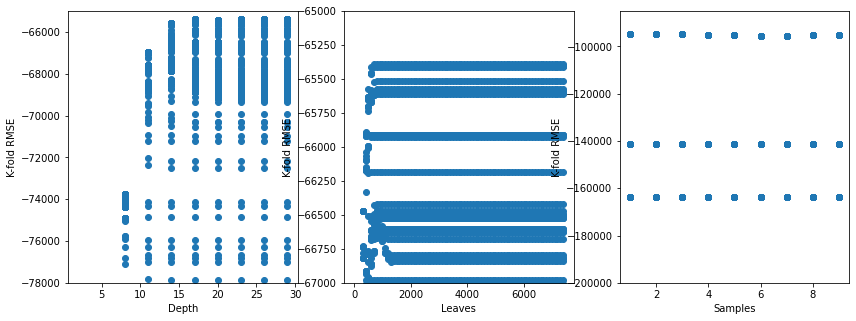

```python
cv_results = pd.DataFrame(model.cv_results_)
fig, axes = plt.subplots(1,3,figsize=(14,5))
plt.subplots_adjust(wspace=0.2)
axes[0].plot(cv_results.param_max_depth, cv_results.mean_test_neg_mean_absolute_error, 'o')
axes[0].set_ylim([-78000, -65000])
axes[0].set_xlabel('Depth')
axes[0].set_ylabel('K-fold RMSE')
axes[1].plot(cv_results.param_max_leaf_nodes, cv_results.mean_test_neg_mean_absolute_error, 'o')
axes[1].set_ylim([-67000, -65000])
axes[1].set_xlabel('Leaves')
axes[1].set_ylabel('K-fold RMSE')
axes[2].plot(cv_results.param_min_samples_leaf, cv_results.mean_test_neg_mean_absolute_error, 'o')
axes[2].set_ylim([-200000, -85000])
axes[2].set_xlabel('Samples')
axes[2].set_ylabel('K-fold RMSE')
```

```python
parameters = {'max_depth':range(13,20),'max_leaf_nodes':range(100,1001,10), 'min_samples_leaf':range(6,10)}
cv = KFold(n_splits = 5,shuffle=True,random_state=45)
model = GridSearchCV(DecisionTreeRegressor(random_state=45), parameters, n_jobs=-1,verbose=1,cv=cv)
model.fit(X_train, y_train)
print (model.best_score_, model.best_params_)
```

```
Fitting 5 folds for each of 2548 candidates, totalling 12740 fits
0.8274028530455594 {'max_depth': 14, 'max_leaf_nodes': 540, 'min_samples_leaf': 8}
```

```python
model = DecisionTreeRegressor(random_state=45, max_depth=14,max_leaf_nodes=540,min_samples_leaf=8)
model.fit(X_train, y_train)

y_pred = model.predict(X_test)
mean_absolute_error(y_test, y_pred)
```

```
64792.00735615428
```

**Optimal Hyperparameters:**

1. max_depth = 14
2. max_leaf_nodes = 540
3. min_samples_leaf = 8

**Test MAE: 64792.00735615428**

### Bagging decision trees

Bag decision trees, and compute the MAE on test data. Use enough number of trees, such that the MAE stabilizes. Other than `n_estimators`, use default values of hyperparameters.

The test MAE must be less than $50,000.

*(4 points)*

```python
bag = BaggingRegressor(base_estimator=DecisionTreeRegressor(random_state=45), n_estimators=200)

bag.fit(X_train, y_train)

y_pred = bag.predict(X_test)

mean_absolute_error(y_test, y_pred)
```

```
47850.69219271487
```

**Test MAE: 47850.69219271487**

### Bagging without bootstrapping

Bag decision trees without bootstrapping, i.e., put `bootstrap = False` while bagging the trees, and compute the MAE on test data. Why is the MAE obtained much higher than that in the previous question, but lower than that obtained in [C.1.2](https://nustat.github.io/STAT303-3-class-notes/Assignment%20C.html#decision-tree)?

*(1 point for code, (3 + 3) points for reasoning)*

```python
bag = BaggingRegressor(base_estimator=DecisionTreeRegressor(random_state=45), n_estimators=200, bootstrap = False)

bag.fit(X_train, y_train)

y_pred = bag.predict(X_test)

mean_absolute_error(y_test, y_pred)
```

```
66407.20801991747
```

**Test MAE: 66407.20801991747**

**When bootstrapping is set to false, each decision tree is trained on the entire training dataset rather than a random sample of the dataset. This leads to higher bias and underfitting which can cause a higher test MAE when dealing with the test dataset.**

**Despite the lack of bootstrapping, this method still produces a better MAE than the single decision tree because variance is still reduced by averaging the predictions of multiple trees. One single model can suffer from high variance if data is noisy.**

### Tuning bagged tree model

#### Approaches

There are two approaches for tuning a bagged tree model:

1. Out of bag predicition
2. $K$-fold cross validation using `GridSearchCV`.

What is the advantage of each approach over the other, i.e., what is the advantage of the out-of-bag approach over $K$-fold cross validation, and what is the advantage of $K$-fold cross validation over the out-of-bag approach?

*(3 + 3 points)*

**OOB prediction can be a more computationally efficient way to estimate the performance and tune the bagged model’s hyperparameters, especially when the dataset is small or when it is expensive to obtain additional data for cross-validation.**

**K-fold CV can provide a more accurate estimate of the performance and can be used to tune a larger number of hyperparameters.**

#### Tuning the hyperparameters

Tune the hyperparameters of the bagged tree model developed in [C.1.4](https://nustat.github.io/STAT303-3-class-notes/Assignment%20C.html#bagging-decision-trees). You may use either of the approaches mentioned in the previous question. Show the optimal values of the hyperparameters obtained. Compute the MAE on test data with the tuned model. Your MAE on test data must be less than $46,000. However, you **cannot use the test data to tune the hyperparameters**.

It is up to you to pick the hyperparameters and their values in the grid.

*(10 points)*

```python
params = {'n_estimators': [500,550,600,650],
          'max_features': [0.7,0.75,0.8]}

cv = KFold(n_splits=5,shuffle=True,random_state=45)
bagging_regressor_grid = GridSearchCV(BaggingRegressor(random_state=45, n_jobs=-1),
                                      param_grid=params, cv=cv, n_jobs=-1, verbose=1,
                                     scoring = 'neg_mean_absolute_error', refit = 'neg_mean_absolute_error')
bagging_regressor_grid.fit(X_train, y_train)
```

```
Fitting 5 folds for each of 12 candidates, totalling 60 fits
```

```
GridSearchCV(cv=KFold(n_splits=5, random_state=45, shuffle=True),
             estimator=BaggingRegressor(n_jobs=-1, random_state=45), n_jobs=-1,
             param_grid={'max_features': [0.7, 0.75, 0.8],
                         'n_estimators': [500, 550, 600, 650]},
             refit='neg_mean_absolute_error', scoring='neg_mean_absolute_error',
             verbose=1)
```

```python
print('Best Parameters : ',bagging_regressor_grid.best_params_)
```

```
Best Parameters :  {'max_features': 0.8, 'n_estimators': 650}
```

```python
model = BaggingRegressor(base_estimator=DecisionTreeRegressor(), n_estimators=650, random_state=45,
                         n_jobs=-1,max_features=0.8).fit(X_train, y_train)
mean_absolute_error(y_test, model.predict(X_test))
```

```
45933.8041188339
```

**TEST MAE: 45933.8041188339**

### Bagging feature importance

Arrange and print the predictors in decreasing order of importance.

*(4 points)*

```python
total = [0] * 15
count = [0] * 15
predictor_names = X_train.columns.tolist() # Get the list of predictor names

for i, temp_model in enumerate(model.estimators_):
    feature = model.estimators_features_[i]
    for j, predictor in enumerate(feature):
        total[predictor] += temp_model.feature_importances_[j]
        count[predictor] += 1

# Calculate the average feature importance score for each predictor
average_feature_importances = np.array(total) / np.array(count)

# Pair the predictor names with their corresponding feature importances
feature_importances_with_names = zip(predictor_names, average_feature_importances)

# Sort the feature importances in descending order
sorted_feature_importances = sorted(feature_importances_with_names, key=lambda x: x[1], reverse=True)

# Print the feature importances with their corresponding names
for predictor, importance in sorted_feature_importances:
    print(f"{predictor}: {importance}")
```

```
TOT_LVG_AREA: 0.43084765497101024
OCEAN_DIST: 0.17503722217914594
CNTR_DIST: 0.12208245357417043
structure_quality: 0.11408737267295155
LONGITUDE: 0.09104676501766494
SPEC_FEAT_VAL: 0.06126323961520675
SUBCNTR_DI: 0.0608196059055224
WATER_DIST: 0.04510397449754187
LND_SQFOOT: 0.04367200668158609
LATITUDE: 0.03213677153397897
age: 0.030923368019643616
RAIL_DIST: 0.023166019612721602
HWY_DIST: 0.021993206284759294
month_sold: 0.006762025515465747
avno60plus: 0.0003014932266609298
```

### Random forest

#### Tuning random forest

Tune a random forest model to predict `SALE_PRC`, and compute the MAE on test data. The MAE must be less than $46,000.

It is up to you to pick the hyperparameters and their values in the grid.

*(10 points)*

```python
params = {'max_depth': [24,25,26],
          'max_leaf_nodes':[3600,3650,3675,3700],
          'max_features': [4],
          'bootstrap': [True, False]}


param_list=list(it.product(*(params[Name] for Name in params)))

oob_MAE = {}; test_MAE = {}
oob_score = [0]*len(param_list)
i=0
for pr in param_list:
    model = RandomForestRegressor(random_state=45,verbose=False,n_estimators = 950,
                                 max_depth=pr[0],
                                  max_leaf_nodes=pr[1],max_features=pr[2],bootstrap=pr[3],
                                  n_jobs=-1).fit(X_train,y_train)
    #oob_MAE[i] = mean_absolute_error(model.oob_prediction_,y_train)
    test_MAE[i] = mean_absolute_error(model.predict(X_test),y_test)
    i=i+1

min_idx = min(test_MAE, key=test_MAE.get)


min_params = param_list[min_idx]


print("Minimum test MAE:", test_MAE[min_idx])
print("Corresponding parameters:", {"max_depth": min_params[0], "max_leaf_nodes": min_params[1], "max_features": min_params[2], "bootstrap":min_params[3]})
```

```
Minimum test MAE: 45393.77102983308
Corresponding parameters: {'max_depth': 24, 'max_leaf_nodes': 3700, 'max_features': 4, 'bootstrap': False}
```

```python
model = RandomForestRegressor(n_estimators=950, random_state=45,max_leaf_nodes=3700,max_depth=24,
                              n_jobs=-1, max_features=4, bootstrap=False).fit(X_train, y_train)
mean_absolute_error(y_test, model.predict(X_test))
```

```
45393.77102983308
```

**Test MAE: 45393.77102983308**

#### Feature importance

Arrange and print the predictors in decreasing order of importance.

*(4 points)*

```python
sorted_indices = model.feature_importances_.argsort()[::-1]
sorted_importance = model.feature_importances_[sorted_indices]


feature_names = np.array(X_train.columns)


for i in range(len(sorted_indices)):
    print(f"{feature_names[sorted_indices[i]]}: {sorted_importance[i]}")
```

```
TOT_LVG_AREA: 0.25745774849104125
OCEAN_DIST: 0.12893808210548025
structure_quality: 0.10394068808407791
SPEC_FEAT_VAL: 0.08771153898454322
SUBCNTR_DI: 0.07962559420054412
LONGITUDE: 0.07192191478411895
CNTR_DIST: 0.06889017528293814
LND_SQFOOT: 0.05324511981501155
LATITUDE: 0.040298486890280025
WATER_DIST: 0.033555765396670864
age: 0.025931898923832127
HWY_DIST: 0.0234635113174661
RAIL_DIST: 0.019410045494178702
month_sold: 0.005118696092206868
avno60plus: 0.0004907341376102452
```

#### Random forest vs bagging: `max_features`

Note that the `max_features` hyperparameter is there both in the `RandomForestRegressor()` function and the `BaggingRegressor()` function. Does it have the same meaning in both the functions? If not, then what is the difference?

**Hint:** Check scikit-learn documentation

*(1 + 3 points)*

**They do not have the same meaning.**

**In RandomForestRegressor(), max_features determines the maximum number of features to consider at each split. A subset of features of size max_features is randomly selected at each node.**

**For BaggingRegressor(), max_features determines the number of features to draw from the predictor set to train each estimator.**

## Classification - Term deposit

The data for this question is related with direct marketing campaigns of a Portuguese banking institution. The marketing campaigns were based on phone calls, where bank clients were called to subscribe for a term deposit.

There is a train data - *train.csv*, which you will use to develop a model. There is a test data - *test.csv*, which you will use to test your model. Each dataset has the following attributes about the clients called in the marketing campaign:

1. `age`: Age of the client
2. `education`: Education level of the client
3. `day`: Day of the month the call is made
4. `month`: Month of the call
5. `y`: did the client subscribe to a term deposit?
6. `duration`: Call duration, in seconds. This attribute highly affects the output target (e.g., if `duration`=0 then `y`=‘no’). Yet, the duration is not known before a call is performed. Also, after the end of the call `y` is obviously known. Thus, this input should only be included for inference purposes and should be discarded if the intention is to have a realistic predictive model.

(Raw data source: [Source](https://archive.ics.uci.edu/ml/datasets/bank+marketing). Do not use the raw data source for this assignment. It is just for reference.)

### Data preparation

Convert all the categorical predictors in the data to dummy variables. Note that `month` and `education` are categorical variables.

*(2 points)*

```python
train = pd.read_csv('train-5.csv')
test = pd.read_csv('test-2.csv')

train = train.drop(columns='duration')
test = test.drop(columns = 'duration')

train = pd.get_dummies(train, columns=['education', 'month'])
test = pd.get_dummies(test, columns=['education', 'month'])

train['y'] = train['y'].replace(['yes', 'no'], [1, 0])
test['y'] = test['y'].replace(['yes', 'no'], [1, 0])
```

```python
X_train = train.drop(columns = 'y')
X_test = test.drop(columns = 'y')
y_train = train['y']
y_test = test['y']
```

### Decision tree

Develop and tune a **decision tree model** to predict the probability of a client subscribing to a term deposit based on `age`, `education`, `day` and `month`. The model must have:

1. **Minimum overall classification accuracy of 70%** among the classifcation accuracies on *train.csv*, and *test.csv*.
2. **Minimum recall of 60%** among the recall on *train.csv*, and *test.csv*.

Print the accuracy and recall for both the datasets - *train.csv*, and *test.csv*.

Note that:

1. You cannot use `duration` as a predictor. The predictor is not useful for prediction because its value is determined after the marketing call ends. However, after the call ends, we already know whether the client responded positively or negatively.
2. You are free to choose any value of threshold probability for classifying observations. However, you must use the same threshold on both the datasets.
3. Use cross-validation on train data to optimize the model hyperparameters.
4. Using the optimal model hyperparameters obtained in (iii), develop the decision tree model. Plot the 5-fold cross-validated accuracy and recall against decision threshold probability. Tune the decision threshold probability based on the plot, or the data underlying the plot to achieve the required trade-off between recall and accuracy.
5. Evaluate the accuracy and recall of the developed model with the tuned decision threshold probability on both the datasets. Note that the test dataset must only be used to evaluate performance metrics, and not optimize any hyperparameters or decision threshold probability.

*(14 points - 4 points for tuning the hyperparameters, 4 points for making the plot, 4 points for tuning the decision threshold probability based on the plot, and 2 points for printing the accuracy & recall on both the datasets)*

**Hint:** Restrict the search for `max_depth` to a maximum of 25, and `max_leaf_nodes` to a maximum of 50. Without this restriction, you may get a better recall for threshold probability = 0.5, but are likely to get a worse trade-off between recall and accuracy.

It is up to you to pick the hyperparameters and their values in the grid.

```python
param_grid = {
    'max_depth': range(1,26),
    'max_leaf_nodes': range(1,51),
    'max_features': [5,6,7]
}

skf = StratifiedKFold(n_splits=5)


grid_search = GridSearchCV(DecisionTreeClassifier(random_state=4), param_grid, scoring=['accuracy','recall'],
                           refit="recall", cv=skf, n_jobs=-1, verbose = True)
grid_search.fit(X_train, y_train)


y_pred = grid_search.predict(X_test)

print('Train accuracy : %.3f' % grid_search.best_estimator_.score(X_train, y_train))
print('Test accuracy : %.3f' % grid_search.best_estimator_.score(X_test, y_test))
print('Best accuracy Through Grid Search : %.3f' % grid_search.best_score_)
print('Best recall : %.3f' % grid_search.best_score_)
print('Best params for recall :', grid_search.best_params_)
```

```
Fitting 5 folds for each of 3750 candidates, totalling 18750 fits
```

```
Train accuracy : 0.886
Test accuracy : 0.888
Best accuracy Through Grid Search : 0.138
Best recall : 0.138
Best params for recall : {'max_depth': 17, 'max_features': 6, 'max_leaf_nodes': 46}
```

```python
model = DecisionTreeClassifier(random_state=4, max_depth=17, max_leaf_nodes=46, max_features=6).fit(X_train, y_train)

y_pred_prob_test = model.predict_proba(X_test)[:, 1]

results = []

for threshold in np.arange(0, 1, 0.1):
    y_pred_test = (y_pred_prob_test > threshold).astype(int)
    accuracy = accuracy_score(y_test, y_pred_test)
    recall = recall_score(y_test, y_pred_test)
    results.append((threshold, accuracy, recall))

results_filtered = [result for result in results if result[1] > 0.7]

results_sorted = sorted(results_filtered, key=lambda x: x[2], reverse=True)

print('Decision threshold:', results_sorted[0][0])
print('Accuracy:', results_sorted[0][1])
print('Recall:', results_sorted[0][2])
```

```
Decision threshold: 0.1
Accuracy: 0.7182547446683624
Recall: 0.6205733558178752
```

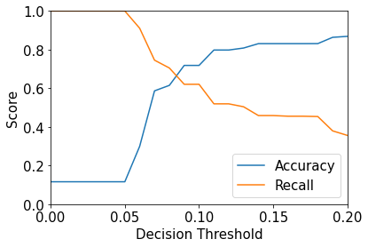

```python
model = DecisionTreeClassifier(random_state=4, max_depth=17, max_leaf_nodes=46, max_features=6).fit(X_train, y_train)
y_pred_prob_test = model.predict_proba(X_test)[:, 1]

results = []

for threshold in np.arange(0, 1, 0.01):
    y_pred_test = (y_pred_prob_test > threshold).astype(int)
    accuracy = accuracy_score(y_test, y_pred_test)
    recall = recall_score(y_test, y_pred_test)
    results.append((threshold, accuracy, recall))

thresholds = [result[0] for result in results]
accuracies = [result[1] for result in results]
recalls = [result[2] for result in results]

plt.plot(thresholds, accuracies, label='Accuracy')
plt.plot(thresholds, recalls, label='Recall')
plt.xlabel('Decision Threshold')
plt.ylabel('Score')
plt.xlim(0, 0.2)
plt.ylim(0, 1.0)
plt.legend()
```

```python
results_filtered = [result for result in results if result[1] > 0.7]

results_sorted = sorted(results_filtered, key=lambda x: x[2], reverse=True)

print('Decision threshold:', results_sorted[0][0])
print('Accuracy:', results_sorted[0][1])
print('Recall:', results_sorted[0][2])
```

```
Decision threshold: 0.09
Accuracy: 0.7182547446683624
Recall: 0.6205733558178752
```

```python
model = DecisionTreeClassifier(random_state=4, max_depth=17, max_leaf_nodes=46, max_features=6).fit(X_train, y_train)

desired_threshold = 0.09

y_pred_prob_train = model.predict_proba(X_train)[:,1]
y_pred_train = y_pred_prob_train > desired_threshold
y_pred_train = y_pred_train.astype(int)
print("Train accuracy: ",accuracy_score(y_pred_train, y_train)*100)
print("Train recall: ", recall_score(y_train, y_pred_train))

# For test dataset
y_pred_prob_test = model.predict_proba(X_test)[:,1]
y_pred_test = y_pred_prob_test > desired_threshold
y_pred_test = y_pred_test.astype(int)
print("Test accuracy: ",accuracy_score(y_pred_test, y_test)*100)
print("Test recall: ", recall_score(y_test, y_pred_test))
```

```
Train accuracy:  71.62571428571428
Train recall:  0.6064814814814815
Test accuracy:  71.82547446683624
Test recall:  0.6205733558178752
```

### Random forest

Develop and tune a **random forest model** to predict the probability of a client subscribing to a term deposit based on `age`, `education`, `day` and `month`. The model must have:

1. **Minimum overall classification accuracy of 75%** among the classifcation accuracies on *train.csv*, and *test.csv*.
2. **Minimum recall of 60%** among the recall on *train.csv*, and *test.csv*.

Print the accuracy and recall for both the datasets - *train.csv*, and *test.csv*.

Note that:

1. You cannot use `duration` as a predictor. The predictor is not useful for prediction because its value is determined after the marketing call ends. However, after the call ends, we already know whether the client responded positively or negatively.
2. You are free to choose any value of threshold probability for classifying observations. However, you must use the same threshold on both the datasets.
3. Use cross-validation on train data to optimize the model hyperparameters.
4. Using the optimal model hyperparameters obtained in (iii), develop the decision tree model. Plot the cross-validated accuracy and recall against decision threshold probability. Tune the decision threshold probability based on the plot, or the data underlying the plot to achieve the required trade-off between recall and accuracy.
5. Evaluate the accuracy and recall of the developed model with the tuned decision threshold probability on both the datasets. Note that the test dataset must only be used to evaluate performance metrics, and not optimize any hyperparameters or decision threshold probability.

*(12 points - 4 points for tuning the hyperparameters, 3 points for making the plot, 3 points for tuning the decision threshold probability based on the plot, and 2 points for printing the accuracy & recall on both the datasets)*

**Hint:** Restrict the search for `max_depth` to a maximum of 25, and `max_leaf_nodes` to a maximum of 45. Without this restriction, you may get a better recall for threshold probability = 0.5, but are likely to get a worse trade-off between recall and accuracy.

It is up to you to pick the hyperparameters and their values in the grid.

```python
params = {
    'max_depth': range(2, 16, 2),
    'max_leaf_nodes': range(20, 40, 2),
    'max_features': [2,3,4],
}

param_list = list(it.product(*(params[name] for name in params)))
recall_scores = [0] * len(param_list)
acc_scores = [0] * len(param_list)

for i, pr in enumerate(param_list):
    model = RandomForestClassifier(
        random_state=4,
        verbose=False,
        max_depth=pr[0],
        max_leaf_nodes=pr[1],
        max_features=pr[2],
        n_jobs=-1,
    ).fit(X_train, y_train)
    y_pred = model.predict(X_test)
    recall_scores[i] = recall_score(y_test, y_pred)
    acc_scores[i] = accuracy_score(y_test, y_pred)

best_params_acc = param_list[np.argmax(acc_scores)]
best_params_rec = param_list[np.argmax(recall_scores)]
best_recall = np.max(recall_scores)
best_acc = np.max(acc_scores)

print('Best params:', best_params_acc, best_params_rec)
print('Best acc/recall:', best_acc, best_recall)
```

```
Best params: (6, 34, 3) (12, 38, 4)
Best acc/recall: 0.8841713950303267 0.011804384485666104
```

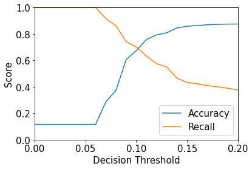

```python
model = RandomForestClassifier(n_estimators=500, random_state=4, max_depth=12, max_leaf_nodes=38, max_features=4).fit(X_train, y_train)
y_pred_prob_test = model.predict_proba(X_test)[:, 1]

results = []

for threshold in np.arange(0, 1, 0.01):
    y_pred_test = (y_pred_prob_test > threshold).astype(int)
    accuracy = accuracy_score(y_test, y_pred_test)
    recall = recall_score(y_test, y_pred_test)
    results.append((threshold, accuracy, recall))

thresholds = [result[0] for result in results]
accuracies = [result[1] for result in results]
recalls = [result[2] for result in results]

plt.plot(thresholds, accuracies, label='Accuracy')
plt.plot(thresholds, recalls, label='Recall')
plt.xlabel('Decision Threshold')
plt.ylabel('Score')
plt.xlim(0, 0.2)
plt.ylim(0, 1.0)
plt.legend()
```

```python
results_filtered = [result for result in results if result[1] > 0.75]

results_sorted = sorted(results_filtered, key=lambda x: x[2], reverse=True)

print('Decision threshold:', results_sorted[0][0])
print('Accuracy:', results_sorted[0][1])
print('Recall:', results_sorted[0][2])
```

```
Decision threshold: 0.11
Accuracy: 0.758364312267658
Recall: 0.6323777403035413
```

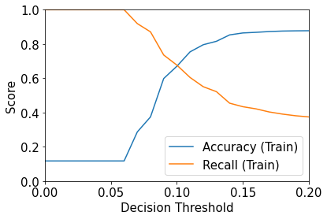

```python
y_pred_prob_train = model.predict_proba(X_train)[:, 1]

results_train = []

for threshold in np.arange(0, 1, 0.01):
    y_pred_train = (y_pred_prob_train > threshold).astype(int)
    accuracy_train = accuracy_score(y_train, y_pred_train)
    recall_train = recall_score(y_train, y_pred_train)
    results_train.append((threshold, accuracy_train, recall_train))

thresholds_train = [result[0] for result in results_train]
accuracies_train = [result[1] for result in results_train]
recalls_train = [result[2] for result in results_train]

plt.plot(thresholds_train, accuracies_train, label='Accuracy (Train)')
plt.plot(thresholds_train, recalls_train, label='Recall (Train)')
plt.xlabel('Decision Threshold')
plt.ylabel('Score')
plt.xlim(0, 0.2)
plt.ylim(0, 1.0)
plt.legend()
```

```python
results_filtered = [result for result in results_train if result[1] > 0.75]

results_sorted = sorted(results_filtered, key=lambda x: x[2], reverse=True)

print('Decision threshold:', results_sorted[0][0])
print('Accuracy:', results_sorted[0][1])
print('Recall:', results_sorted[0][2])
```

```
Decision threshold: 0.11
Accuracy: 0.7541714285714286
Recall: 0.60453216374269
```

```python
model = RandomForestClassifier(n_estimators=500, random_state=4, max_depth=12, max_leaf_nodes=38, max_features=4).fit(X_train, y_train)

desired_threshold = 0.11

y_pred_prob_train = model.predict_proba(X_train)[:,1]
y_pred_train = y_pred_prob_train > desired_threshold
y_pred_train = y_pred_train.astype(int)
print("Train accuracy: ",accuracy_score(y_pred_train, y_train)*100)
print("Train recall: ", recall_score(y_train, y_pred_train))


y_pred_prob_test = model.predict_proba(X_test)[:,1]
y_pred_test = y_pred_prob_test > desired_threshold
y_pred_test = y_pred_test.astype(int)
print("Test accuracy: ",accuracy_score(y_pred_test, y_test)*100)
print("Test recall: ", recall_score(y_test, y_pred_test))
```

```
Train accuracy:  75.41714285714286
Train recall:  0.60453216374269
Test accuracy:  75.8364312267658
Test recall:  0.6323777403035413
```

## Predictor transformations in trees

Can a non-linear monotonic transformation of predictors (such as *log(), sqrt()* etc.) be useful in improving the accuracy of decision tree models?

*(3 points for answer)*

**I think such transformations are minimally useful. Decision trees are usually able to any non-linear relationships between the predictor variables and the target variable without any need for transformations. Decision trees are non-parametric meaning it can create a non-linear fit that depends entirely on the data and its distribution.**